# MACHINE LEARNING APPROACH FOR LOW BIRTH WEIGHT PREDICTION

## OVERVIEW

**Low birth weight(LBW) is a critical issue that affects new born infants all over the world. It has been linked to infant mortality. Predicting LBW is a valuable preventative tool and predictor of newborn health risks. The capstone project employed a machine learning model to predict LBW.**

## OBJECTIVES

**To identify the key maternal factors influencing likelihood of low birth weight**

**To investigate the relationship between low birth weight and maternal history**

## HYPOTHESIS

**Null Hypothesis: There is no relationship between demographic factors and low birth weight**

**Alternative hypothesis: There is a relationship between demographic and low birth weight**

## DATA PREPARATION AND ANALYSIS

[output not shown]

## Importing necessary libraries

```python
import pandas as pd
```

```
C:\Users\Esinta Mphongolo\Anaconda3\lib\site-packages\pandas\compat\_optional.py:138: UserWarning: Pandas requires version '2.7.0' or newer of 'numexpr' (version '2.6.9' currently installed).
  warnings.warn(msg, UserWarning)
```

## Importing the dataset file

*The dataset 'matsurvey_dta.csv' contains data collected by Kamuzu University of Health Sciences' Women in Science project. It contains data of martenal factors(socio-demographic and behavioral) affecting birth weight of infants*

```python
df =pd.read_csv('matsurvey_dta.csv')
```

## Viewing first few rows of the dataset

```python
df.head()
```

|  | Unnamed: 0 | facility_name | age | ward | doadmin | vdrl | hivtest | covid | nearmiss | babies | b1bweight | Zone | gest_age | dist | tt_arrv |
| --- | --- | --- | --- | --- | --- | --- | --- | --- | --- | --- | --- | --- | --- | --- | --- |
| 0 | 1 | Bwaila | 22.562628 | 7 | 2020-10-04 | 99 | 0 | 0 | 1 | 1 | 3000 | Central West | 39.793851 | 13.450458 | 16.220360 |
| 1 | 2 | Bwaila | 28.772074 | 7 | 2020-10-06 | 0 | 0 | 0 | 1 | 1 | 3500 | Central West | 38.017257 | 3.982630 | 10.117301 |
| 2 | 3 | Bwaila | 23.819302 | 7 | 2020-10-08 | 0 | 0 | 0 | 1 | 1 | 3500 | Central West | 39.079171 | 5.581858 | 9.080061 |
| 3 | 4 | Bwaila | 29.702943 | 2 | 2020-10-16 | 0 | 0 | 0 | 1 | 1 | 4100 | Central West | 43.721149 | 8.592800 | 17.178469 |
| 4 | 5 | Bwaila | 21.798768 | 7 | 2020-10-18 | 99 | 0 | 0 | 1 | 1 | 2800 | Central West | 39.422272 | 13.623117 | 16.358216 |

## Viewing the last 60 rows of the dataset

```python
df.tail(60)
```

|  | Unnamed: 0 | facility_name | age | ward | doadmin | vdrl | hivtest | covid | nearmiss | babies | b1bweight | Zone | gest_age | dist | tt_arrv |
| --- | --- | --- | --- | --- | --- | --- | --- | --- | --- | --- | --- | --- | --- | --- | --- |
| 996 | 997 | Balaka | 25.000000 | 2 | 2021-12-12 | 0 | 0 | 0 | 1 | 1 | 3600 | South East | 42.703930 | 11.652510 | 15.479578 |
| 997 | 998 | Balaka | 37.000000 | 2 | 2021-12-25 | 0 | 0 | 0 | 1 | 1 | 2500 | South East | 35.988671 | 9.539248 | 18.275706 |
| 998 | 999 | Balaka | 44.000000 | 2 | 2021-12-24 | 0 | 0 | 0 | 1 | 1 | 3500 | South East | 38.438300 | 4.232044 | 10.329406 |
| 999 | 1000 | Balaka | 17.000000 | 2 | 2022-01-08 | 99 | 0 | 0 | 1 | 1 | 3400 | South East | 36.385950 | 2.868892 | 8.526999 |
| 1000 | 1001 | Balaka | 34.000000 | 6 | 2022-01-06 | 0 | 0 | 1 | 0 | 2 | 2800 | South East | 36.853816 | 3.983051 | 10.284153 |
| 1001 | 1002 | Balaka | 16.339493 | 7 | 2022-02-17 | 0 | 0 | 0 | 1 | 1 | 2000 | South East | 41.458548 | 7.962132 | 8.386120 |
| 1002 | 1003 | Balaka | 19.069131 | 2 | 2022-02-27 | 0 | 0 | 0 | 1 | 1 | 2700 | South East | 40.435130 | 10.272914 | 13.218406 |
| 1003 | 1004 | Balaka | 16.000000 | 1 | 2022-02-28 | 0 | 0 | 0 | 1 | 1 | 2100 | South East | 35.685195 | 5.749251 | 13.233266 |
| 1004 | 1005 | Balaka | 23.000000 | 1 | 2022-02-28 | 0 | 0 | 0 | 1 | 1 | 2700 | South East | 38.708827 | 14.324820 | 19.443771 |
| 1005 | 1006 | Balaka | 17.000000 | 2 | 2022-03-06 | 0 | 0 | 0 | 1 | 1 | 2800 | South East | 39.766703 | 1.775349 | 7.929781 |
| 1006 | 1007 | Balaka | 26.000000 | 2 | 2022-05-16 | 0 | 0 | 0 | 1 | 1 | 3500 | South East | 39.419906 | 0.586501 | 7.925907 |
| 1007 | 1008 | Balaka | 18.000000 | 2 | 2022-05-15 | 99 | 99 | 0 | 1 | 1 | 3100 | South East | 42.887066 | 7.567575 | 17.888889 |
| 1008 | 1009 | Balaka | 30.000000 | 2 | 2022-05-22 | 0 | 0 | 0 | 1 | 1 | 2800 | South East | 39.206608 | 8.677238 | 9.901976 |
| 1009 | 1010 | Balaka | 22.000000 | 2 | 2022-05-23 | 0 | 0 | 0 | 1 | 1 | 2900 | South East | 40.970638 | 12.589559 | 18.998797 |
| 1010 | 1011 | Balaka | 21.000000 | 2 | 2022-06-26 | 99 | 99 | 0 | 1 | 2 | 3200 | South East | 39.252051 | 9.816675 | 16.479498 |
| 1011 | 1012 | Balaka | 37.541410 | 7 | 2022-07-21 | 99 | 0 | 0 | 1 | 1 | 1200 | South East | 34.832050 | 14.167925 | 20.006419 |
| 1012 | 1013 | Balaka | 39.000000 | 2 | 2022-07-21 | 0 | 0 | 0 | 1 | 1 | 2600 | South East | 40.515127 | 7.674864 | 15.380798 |
| 1013 | 1014 | Balaka | 39.000000 | 2 | 2022-07-21 | 0 | 0 | 0 | 1 | 1 | 2200 | South East | 36.281226 | 1.273816 | 8.147017 |
| 1014 | 1015 | Balaka | 22.000000 | 2 | 2022-08-21 | 0 | 0 | 0 | 1 | 1 | 3000 | South East | 38.389340 | 14.921558 | 21.315465 |
| 1015 | 1016 | Balaka | 18.000000 | 2 | 2022-02-09 | 0 | 0 | 0 | 1 | 1 | 2800 | South East | 41.505379 | 6.021662 | 13.144049 |
| 1016 | 1017 | Balaka | 22.000000 | 7 | 2022-10-22 | 0 | 0 | 0 | 1 | 1 | 3000 | South East | 40.852074 | 13.434694 | 20.070456 |
| 1017 | 1018 | Zomba DHO | 28.320329 | 1 | 2022-04-28 | 0 | 1 | 0 | 1 | 1 | 4800 | South East | 37.258450 | 13.152876 | 15.520085 |
| 1018 | 1019 | QECH | 17.000000 | 7 | 2022-12-19 | 0 | 0 | 0 | 1 | 1 | 1400 | South West | 40.673589 | 4.447272 | 11.932396 |
| 1019 | 1020 | QECH | 17.000000 | 7 | 2022-12-27 | 0 | 0 | 0 | 1 | 1 | 3140 | South West | 36.394359 | 1.988879 | 11.545726 |
| 1020 | 1021 | QECH | 15.843943 | 7 | 2022-12-28 | 0 | 0 | 0 | 1 | 1 | 2500 | South West | 36.873342 | 3.988664 | 10.826667 |
| 1021 | 1022 | QECH | 19.000000 | 7 | 2022-12-23 | 0 | 0 | 0 | 1 | 1 | 1500 | South West | 39.708179 | 0.085913 | 5.470375 |
| 1022 | 1023 | QECH | 18.746064 | 7 | 2023-01-11 | 99 | 0 | 0 | 1 | 1 | 2700 | South West | 40.311038 | 12.294027 | 19.615449 |
| 1023 | 1024 | QECH | 18.000000 | 2 | 2023-01-15 | 0 | 0 | 0 | 1 | 1 | 3200 | South West | 38.752212 | 2.619925 | 5.841926 |
| 1024 | 1025 | QECH | 18.000000 | 7 | 2023-02-10 | 99 | 99 | 0 | 1 | 2 | 1800 | South West | 38.148648 | 12.646208 | 15.114972 |
| 1025 | 1026 | QECH | 21.000000 | 7 | 2023-03-07 | 99 | 0 | 0 | 1 | 2 | 1900 | South West | 35.372800 | 2.500683 | 7.878410 |
| 1026 | 1027 | QECH | 21.000000 | 7 | 2023-03-16 | 99 | 0 | 0 | 1 | 1 | 1300 | South West | 40.214987 | 11.460292 | 15.890517 |
| 1027 | 1028 | QECH | 27.334702 | 7 | 2023-03-18 | 0 | 0 | 0 | 1 | 1 | 1800 | South West | 41.023120 | 7.784071 | 17.012126 |
| 1028 | 1029 | Chikwawa | 24.000000 | 7 | 2023-03-19 | 0 | 0 | 0 | 1 | 1 | 2700 | South West | 38.211770 | 4.090280 | 6.113354 |
| 1029 | 1030 | Mangochi | 30.000000 | 7 | 2023-03-07 | 0 | 0 | 0 | 1 | 1 | 3700 | South East | 41.189556 | 5.148047 | 11.531371 |
| 1030 | 1031 | Mangochi | 30.000000 | 7 | 2023-03-07 | 0 | 0 | 0 | 1 | 1 | 3700 | South East | 39.203319 | 10.576130 | 15.476437 |
| 1031 | 1032 | Mwanza | 38.472279 | 2 | 2022-11-23 | 0 | 0 | 0 | 1 | 1 | 2700 | South West | 38.142121 | 8.873030 | 15.920592 |
| 1032 | 1033 | Mwanza | 35.707050 | 2 | 2022-12-20 | 99 | 0 | 0 | 1 | 1 | 3300 | South West | 36.888383 | 7.040686 | 13.657805 |
| 1033 | 1034 | Mwanza | 34.165640 | 2 | 2023-02-27 | 0 | 0 | 0 | 1 | 1 | 2700 | South West | 35.280461 | 5.045649 | 8.132334 |
| 1034 | 1035 | Mwanza | 19.175907 | 2 | 2023-02-22 | 99 | 99 | 0 | 1 | 1 | 3200 | South West | 35.319143 | 14.517561 | 18.053840 |
| 1035 | 1036 | Mwanza | 25.212868 | 2 | 2023-03-13 | 0 | 0 | 0 | 1 | 1 | 3100 | South West | 35.143931 | 9.687628 | 14.452905 |
| 1036 | 1037 | Mwanza | 20.213552 | 2 | 2023-03-18 | 0 | 0 | 0 | 1 | 1 | 2900 | South West | 36.791261 | 2.944518 | 13.116357 |
| 1037 | 1038 | Mwanza | 45.212868 | 2 | 2023-02-28 | 0 | 0 | 0 | 1 | 1 | 2700 | South West | 41.818382 | 5.357706 | 13.591305 |
| 1038 | 1039 | Nkhotakota | 23.118412 | 7 | 2023-02-13 | 0 | 0 | 0 | 1 | 1 | 2500 | Central East | 42.143313 | 7.695271 | 16.824271 |
| 1039 | 1040 | Nkhotakota | 40.125941 | 7 | 2023-02-15 | 1 | 0 | 0 | 1 | 1 | 3600 | Central East | 36.430276 | 13.244951 | 19.800634 |
| 1040 | 1041 | Nkhotakota | 26.817248 | 7 | 2023-02-23 | 0 | 0 | 0 | 1 | 1 | 3300 | Central East | 39.079343 | 2.290013 | 8.192423 |
| 1041 | 1042 | Nkhotakota | 34.981520 | 7 | 2023-03-12 | 0 | 0 | 0 | 1 | 1 | 1400 | Central East | 36.067969 | 3.456924 | 12.228948 |
| 1042 | 1043 | Nsanje | 25.987680 | 2 | 2022-12-26 | 0 | 0 | 0 | 1 | 1 | 2000 | South West | 34.804731 | 2.444829 | 11.608875 |
| 1043 | 1044 | Phalombe | 28.000000 | 2 | 2023-01-18 | 0 | 0 | 0 | 1 | 1 | 1900 | South East | 38.010454 | 9.215203 | 15.185798 |
| 1044 | 1045 | Phalombe | 22.000000 | 2 | 2022-12-14 | 99 | 99 | 0 | 1 | 1 | 3300 | South East | 37.560062 | 7.524547 | 16.139220 |
| 1045 | 1046 | Phalombe | 28.000000 | 2 | 2023-01-14 | 1 | 0 | 0 | 1 | 1 | 2800 | South East | 37.633640 | 2.821783 | 9.951664 |
| 1046 | 1047 | Phalombe | 23.000000 | 2 | 2022-10-12 | 0 | 0 | 0 | 1 | 1 | 1800 | South East | 39.067392 | 6.115723 | 15.423927 |
| 1047 | 1048 | Phalombe | 18.000000 | 2 | 2022-10-17 | 0 | 0 | 0 | 1 | 1 | 2700 | South East | 35.231777 | 8.735821 | 14.133305 |
| 1048 | 1049 | Phalombe | 25.000000 | 2 | 2023-01-10 | 1 | 0 | 0 | 1 | 1 | 3000 | South East | 37.571621 | 4.633936 | 10.888230 |
| 1049 | 1050 | Phalombe | 40.000000 | 2 | 2023-01-14 | 0 | 0 | 0 | 1 | 1 | 2700 | South East | 39.470711 | 7.214485 | 14.698586 |
| 1050 | 1051 | Phalombe | 29.000000 | 2 | 2022-11-26 | 0 | 0 | 0 | 1 | 1 | 1100 | South East | 39.106807 | 14.090922 | 19.357756 |
| 1051 | 1052 | Phalombe | 25.000000 | 2 | 2023-02-02 | 0 | 0 | 0 | 1 | 1 | 2300 | South East | 36.423239 | 0.690608 | 4.770238 |
| 1052 | 1053 | Phalombe | 24.000000 | 2 | 2022-12-30 | 0 | 0 | 0 | 1 | 1 | 3700 | South East | 40.662343 | 8.022926 | 12.295133 |
| 1053 | 1054 | Rumphi | 26.206708 | 2 | 2023-03-13 | 0 | 0 | 0 | 1 | 1 | 2500 | North | 35.096671 | 6.639912 | 10.488677 |
| 1054 | 1055 | Balaka | 29.000000 | 2 | 2023-01-03 | 0 | 0 | 0 | 1 | 1 | 2900 | South East | 39.292495 | 13.595482 | 19.080497 |
| 1055 | 1056 | Balaka | 28.000000 | 2 | 2023-02-23 | 0 | 0 | 0 | 1 | 1 | 3200 | South East | 37.419552 | 13.215636 | 15.752191 |

## Checking dataset information

```python
df.info()
```

```
<class 'pandas.core.frame.DataFrame'>
RangeIndex: 1056 entries, 0 to 1055
Data columns (total 15 columns):
 #   Column         Non-Null Count  Dtype
---  ------         --------------  -----
 0   Unnamed: 0     1056 non-null   int64
 1   facility_name  1056 non-null   object
 2   age            1056 non-null   float64
 3   ward           1056 non-null   int64
 4   doadmin        1056 non-null   object
 5   vdrl           1056 non-null   int64
 6   hivtest        1056 non-null   int64
 7   covid          1056 non-null   int64
 8   nearmiss       1056 non-null   int64
 9   babies         1056 non-null   int64
 10  b1bweight      1056 non-null   int64
 11  Zone           1056 non-null   object
 12  gest_age       1056 non-null   float64
 13  dist           1056 non-null   float64
 14  tt_arrv        1056 non-null   float64
dtypes: float64(4), int64(8), object(3)
memory usage: 111.4+ KB
```

## Checking the summary statistics

```python
#includes measures of central tendency
df.describe()
```

|  | Unnamed: 0 | age | ward | vdrl | hivtest | covid | nearmiss | babies | b1bweight | gest_age | dist | tt_arrv |
| --- | --- | --- | --- | --- | --- | --- | --- | --- | --- | --- | --- | --- |
| count | 1056.000000 | 1056.000000 | 1056.000000 | 1056.000000 | 1056.000000 | 1056.000000 | 1056.000000 | 1056.000000 | 1056.000000 | 1056.000000 | 1056.000000 | 1056.000000 |
| mean | 528.500000 | 26.565001 | 4.200758 | 23.090909 | 7.074811 | 0.161932 | 0.866477 | 1.047348 | 2793.590909 | 38.930924 | 7.507421 | 13.326313 |
| std | 304.985246 | 7.233237 | 2.487398 | 41.853132 | 25.430233 | 0.368563 | 0.340300 | 0.216899 | 709.853763 | 2.379665 | 4.327559 | 4.032582 |
| min | 1.000000 | 10.841889 | 1.000000 | 0.000000 | 0.000000 | 0.000000 | 0.000000 | 1.000000 | 99.000000 | 32.196144 | 0.019720 | 2.894980 |
| 25% | 264.750000 | 20.292266 | 2.000000 | 0.000000 | 0.000000 | 0.000000 | 1.000000 | 1.000000 | 2450.000000 | 36.954185 | 3.902677 | 10.293124 |
| 50% | 528.500000 | 25.472964 | 2.000000 | 0.000000 | 0.000000 | 0.000000 | 1.000000 | 1.000000 | 2900.000000 | 39.024330 | 7.279963 | 13.284893 |
| 75% | 792.250000 | 32.000000 | 7.000000 | 1.000000 | 0.000000 | 0.000000 | 1.000000 | 1.000000 | 3200.000000 | 40.828696 | 11.251302 | 16.560409 |
| max | 1056.000000 | 51.115674 | 7.000000 | 99.000000 | 99.000000 | 1.000000 | 1.000000 | 3.000000 | 4800.000000 | 44.437234 | 14.998959 | 23.091507 |

## CORRELATION

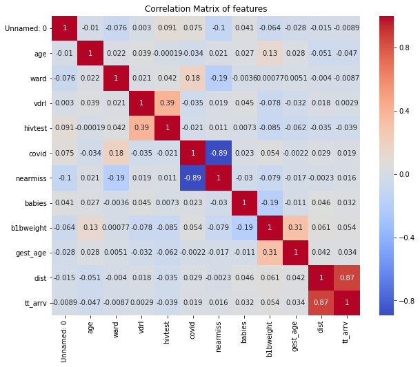

```python
import matplotlib.pyplot as plt
import seaborn as sns
import pandas.util.testing as tm
plt.figure(figsize=(10,8))
sns.heatmap(df.corr(), annot=True, cmap='coolwarm')
plt.title('Correlation Matrix of features')
plt.show()
```

**Correlation ranges from -1 to +1. Values closer to zero means there is no linear trend between the two variables. The close to 1 the correlation is the more positively correlated they are; that is as one increases so does the other and the closer to 1 the stronger this relationship is. A correlation closer to -1 is similar, but instead of both increasing one variable will decrease as the other increases**

## Feature Selection

*selecting the most important features from our dataset to improve model performance*

```python
features = ['age', 'hivtest','covid','gest_age', 'tt_arrv', 'dist']
x=df[features]
y=df['b1bweight']
```

## Importing sckit-learn

*for splitting the dataset and training our model*

```python
from sklearn.model_selection import train_test_split
```

## Splitting the dataset

*Training_size = 80%* *Testing_size = 20%*

**This will help us determine the accuracy of the model**

```python
x_train, x_test, y_train, y_test = train_test_split(x,y, test_size=0.2, random_state=42)
```

*Verifying the dimensions of our train and test sets*

```python
print(x_train.shape, x_test.shape, y_train.shape, y_test.shape)
```

```
(844, 6) (212, 6) (844,) (212,)
```

## Performing Linear Regression

```python
from sklearn.linear_model import LinearRegression
```

```python
model= LinearRegression()
```

**Training the model**

```python
model.fit(x_train, y_train)
```

```
LinearRegression()
```

features = ['age', 'hivtest','covid','gest_age', 'tt_arrv', 'dist']

```python
coefficient = model.coef_
print('Coefficients:', coefficient)
```

```
Coefficients: [11.45911319 -2.10407408 75.94124905 87.5093549  -7.30474854 13.49192388]
```

## Interpretation

*HIV Test: If HIV Test is positive(1 vs 0), birth-weight **decreases** with 2.10 grams keeping all other factors constant. This shows a weak negative relationship*

*Covid: If COVID history is present, birth-weight increases with 75.94 keeping all other factors constant*

*Gestation period: For each additional week during gestation , birth-weight increases by 87.50 grams keeping all other factors constant*. *This show a positive relationship as longer gestation periods increases the probability of higher birth weight*

*Distance: For every unit increase in distance to the health facility, birth-weight increases by 13.5 keeping all other factors constant*

```python
intercept = model.intercept_
```

## Finding the intercept

```python
print(intercept)
```

```
-938.7775357798478
```

## Model Predictions

*Predictions from the x_test*

```python
y_pred = model.predict(x_test)
print(y_pred)
```

```
[2639.68467081 2648.83168788 2945.99409237 2783.6299895  2644.68737449
 2688.01090255 2702.22214006 2975.32689621 2968.39713571 2875.5314366
 2790.52054486 2952.11468268 2500.34100265 2570.53423633 2767.67309953
 2312.48282013 2895.58715027 3150.30572793 2436.7914263  3051.42366823
 2549.49266833 2729.88949625 3080.18708884 2949.74548694 2786.2485617
 3144.14607285 2516.93376373 2972.54473762 2730.44306618 3223.12159394
 2999.0318278  2940.9360349  2699.52470355 3170.49154822 2967.78292595
 2149.49711101 2614.9529395  2638.36435528 2487.17563767 2635.23171064
 2785.03170261 2769.69347288 2285.62920637 2874.20982716 2864.45831242
 2705.53342697 3038.1455216  2719.31705374 3242.38581327 2553.75428184
 2748.84399776 2775.74435896 2632.12000919 2819.93843583 2285.49551117
 3220.69130818 2559.73481626 3109.90347106 3044.95087334 3052.05807035
 2716.03384677 2763.40402976 2374.66744758 2596.68277109 2677.83598509
 2650.13305211 2720.75434736 2727.01708066 2883.89376235 2355.1314596
 2554.73673281 2488.21286382 2401.0973361  2614.87292389 2841.45981024
 2735.13274701 2928.76981636 2823.15797223 3061.04716739 2975.77536592
 2351.43763271 2232.50476092 3097.2117817  2755.45873643 2372.1537302
 2785.11584688 2658.4228635  2730.56276769 2955.60992653 3108.74526055
 2511.85569617 2536.40937417 2876.45743502 2743.29462875 2671.50461121
 3093.26757771 2836.81089465 2782.11623097 2503.49324115 2494.87503232
 3023.9227579  3119.17596936 2568.73274391 2838.20288782 2787.12684824
 2813.28397979 2440.3285478  2575.52504721 2961.45684304 2728.23045035
 2983.73641311 2549.04729041 2505.19124047 2739.58153756 3050.93258898
 2472.61780179 2611.71577605 3151.41958451 2190.76349632 2520.45519373
 3043.32466517 2530.49263784 2915.73762921 3130.81344679 3179.26516661
 2591.8767126  3287.76300297 3052.60876234 3119.01302978 2720.53048667
 2765.04091099 3317.02062539 2544.91831893 3218.05042474 2707.31742474
 3020.43916651 3003.70504759 2963.02860099 2790.98953697 2839.74785566
 2896.05751004 3041.44881389 3062.38814315 3193.9267624  2548.20584066
 2647.11220517 2440.11350702 2488.14532813 2814.17236817 2765.58259705
 3074.24995427 3268.94754992 2670.2187638  3176.22755977 2709.01918691
 2684.54819875 2751.61366593 2718.4122599  2849.70646897 3130.46762451
 2980.50904336 2993.03788322 2629.75809853 2495.07021102 2960.25529314
 2925.70576498 2559.20797247 3080.73021693 2785.13363217 3141.96461984
 2973.21428859 3069.8365936  2593.29977782 2846.15775686 2543.37539178
 2482.61437363 2762.9460186  2601.58684505 2471.17261093 2649.99121646
 2605.50481054 3063.93174681 3260.50881474 2640.75005621 3129.03714362
 2834.96736268 2749.77753985 2821.95029571 3201.40549406 2643.09543115
 2563.65395298 2716.94690194 3039.98480307 2926.55850438 2625.25229918
 2791.48347225 2782.00377821 2985.17477247 2973.61488237 3126.44291969
 3070.84468682 2490.14480014 2770.74409836 2595.52421682 3113.36270188
 2633.2007796  2846.80653479 2451.50521288 2497.01384794 2736.18011349
 3200.09839934 3008.38006522]
```

## Visualization of model predictions

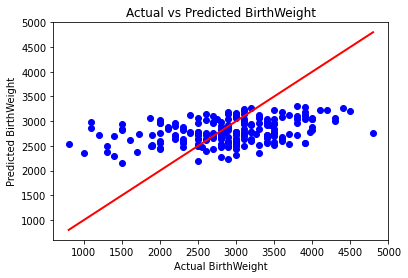

```python
plt.scatter(y_test, y_pred, color='blue')
plt.plot([y_test.min(), y_test.max()], [y_test.min(), y_test.max()], color='red', linewidth=2)
plt.xlabel('Actual BirthWeight')
plt.ylabel('Predicted BirthWeight')
plt.title('Actual vs Predicted BirthWeight')
plt.show()
```

*Interpretation*

**The points close to the red line indicate accurate predictions.**

**Most of the points are near around or slightly over 3000 grams, this means the model evaluates normal weights well but struggles with low or higher birth weights.**

## Finding the best fit

```python
from sklearn.metrics import r2_score, mean_squared_error
```

```python
#calculating R-square
r2 = r2_score(y_pred, y_test)
print("R-Squared:", r2)
```

```
R-Squared: -6.559845206350134
```

```python
# Calculate Mean Squared Error
mse = mean_squared_error(y_test, y_pred)
print("Mean Squared Error:", mse)
```

```
Mean Squared Error: 456985.7774726185
```

## LIMITATIONS

**1. The assumptions of linear regression may not have been met**

## MITIGATING BIAS

**Use non-linear models and include interaction terms**

## CONCLUSION

**Further investigation is needed to be done because the value of R-square is an indication that something is not entire appropriate with the model or data. High MSE indicates that predicting low birth weights rather requires non-linear models in order to predict values closer to the actual values.**